# Classification and diagnostic prediction of cancers using gene expression profiling

Lorena Pelegero

9 de julio, 2021

### **Algoritmo Support Vector Machine**

**Definicion**

El algoritmo Support Vector Machine son modelos de aprendizaje supervisado con algoritmos de aprendizaje asociados que analizan datos para clasificacion y analisis de regresion. Dado un conjunto de ejemplos de entrenamiento, cada uno marcado como perteneciente a una de dos categorias, un algoritmo de entrenamiento de SVM construye un modelo que asigna nuevos ejemplos a una categoria u otra, convirtiendolo en un clasificador lineal binario no probabilistico .

Cuando los datos no estan etiquetados, el aprendizaje supervisado no es posible y se requiere un enfoque de aprendizaje no supervisado , que intenta encontrar la agrupacion natural de los datos en grupos y luego asignar nuevos datos a estos grupos formados.Estos metodos estan propiamente relacionados con problemas de clasificacion y regresion. Dado un conjunto de ejemplos de entrenamiento podemos etiquetar las clases y entrenar una SVM para construir un modelo que prediga la clase de una nueva muestra. Intuitivamente, una SVM es un modelo que representa a los puntos de muestra en el espacio, separando las clases a 2 espacios lo mas amplios posibles mediante un hiperplano de separacion definido como el vector entre los 2 puntos, de las 2 clases, mas cercanos al que se llama vector soporte. Cuando las nuevas muestras se ponen en correspondencia con dicho modelo, en funcion de los espacios a los que pertenezcan, pueden ser clasificadas a una o la otra clase.

**Tabla de fortalezas y debilidades**

| **Fortalezas** | **Debilidades** |
| --- | --- |
| - Versatil | - No adecuadas en grandes conjuntos |
| - Eficiente en memoria | - No proporcionan directamente estimaciones de probabilidad |
| - Buena precision | - No eficientes computacionalmente |
| - Sencillez de los modelos |  |

## Step 1 – collecting data

```r
library(readr)
data7 <- read_csv("C:/Users/usuario/Desktop/UOC/Tercer semestre/Machine learning/PEC 2/data7.csv")
dim(data7)
```

```
## [1]   60 5043
```

```r
clase <- read_csv("C:/Users/usuario/Desktop/UOC/Tercer semestre/Machine learning/PEC 2/class7.csv")
kable(table(clase$x), caption="Tabla con las diferentes clases de tumores")
```

Tabla con las diferentes clases de tumores

| Var1 | Freq |
| --- | --- |
| 1 | 12 |
| 2 | 12 |
| 3 | 12 |
| 4 | 12 |
| 5 | 12 |

Ahora renombramos la variable X y la convertimos en factor para poder trabajar con ella

```r
tipoCancer <- c("ALL","AML","CLL","CML", "NoL")
clase.c <- factor(clase$x,labels=tipoCancer)
table(clase.c)
```

```
## clase.c
## ALL AML CLL CML NoL
##  12  12  12  12  12
```

## Step 2 – exploring and preparing the data

Normalizamos los datos con la siguiente funcion

```r
normalize <- function(x) {
return((x - min(x)) / (max(x) - min(x)))}
```

Aplicamos la funcion de normalizacion a cada columna de nuestra base de datos

```r
pca_norm2 <- as.data.frame(lapply(data7, normalize))
```

Para confirmar que ha funcionado miramos el minimo y el maximo de nuestros datos y lo visualizamos en un grafico boxplot

```r
summary(pca_norm2$ENSG00000001629)
```

```
##    Min. 1st Qu.  Median    Mean 3rd Qu.    Max.
##  0.0000  0.3565  0.5826  0.5302  0.7122  1.0000
```

```r
summary(data7$ENSG00000001629)
```

```
##    Min. 1st Qu.  Median    Mean 3rd Qu.    Max.
##   4.808   6.108   6.932   6.741   7.405   8.454
```

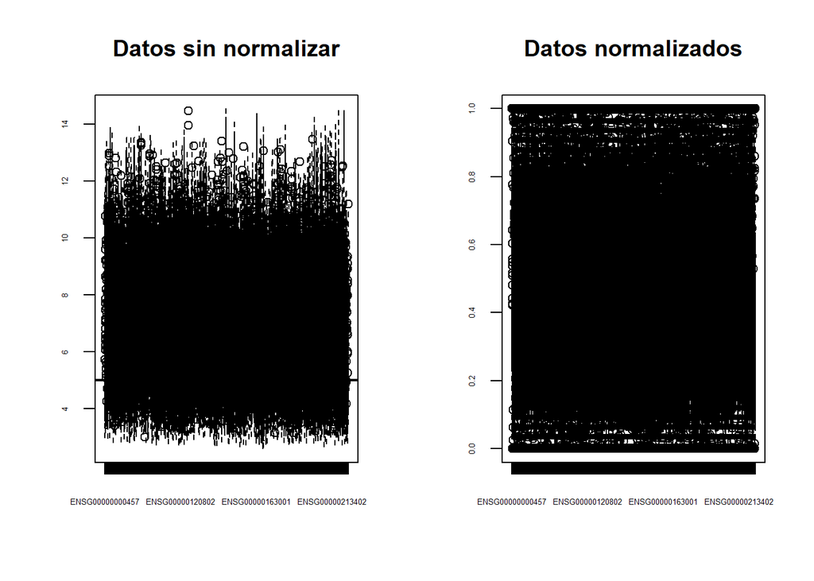

```r
par(mfrow=c(1,2))
boxplot(data7,main='Datos sin normalizar',col='brown',cex.axis=0.4)
abline(h=5,lwd=2)

boxplot(pca_norm2,main='Datos normalizados',col='brown',cex.axis=0.4)
abline(h=5,lwd=2)
```

```r
par(mfrow=c(1,1))
```

Observamos que despues de la normalizacion los datos van del 0 al 1, por tanto, se ha realizado correctamente.

Ahora renombramos la variable X y la convertimos en factor para poder trabajar con ella

```r
tipoCancer <- c("ALL","AML","CLL","CML", "NoL")
clase.f <- factor(clase$x,labels=tipoCancer)
data7$clase <- clase.f
```

Entrenamos el 67% de los datos y probamos el 33%

```r
set.seed(12345)
index <- sample(nrow(data7), round(0.67*nrow(data7)))
data_train <- data7[index,]
data_test <- data7[-index,]
```

## Step 3 – training a model on the data

Instalar Kernlab

```r
set.seed(1234567)
library(kernlab)
model_class <- ksvm(clase ~ ., data = data_train, kernel = "vanilladot")
model_class
```

```
## Support Vector Machine object of class "ksvm"
##
## SV type: C-svc  (classification)
##  parameter : cost C = 1
##
## Linear (vanilla) kernel function.
##
## Number of Support Vectors : 36
##
## Objective Function Value : -8e-04 -5e-04 -3e-04 -4e-04 -4e-04 -8e-04 -0.001 -2e-04 -3e-04 -0.0015
## Training error : 0
```

## Step 4 – evaluating model performance

Observamos las predicciones:

```r
require(caret)
mydata_predict1 <- predict(model_class, data_test)
res <- table(mydata_predict1, data_test$clase)
(conf_mat.s1 <- confusionMatrix(res))
```

```
## Confusion Matrix and Statistics
##
##
## mydata_predict1 ALL AML CLL CML NoL
##             ALL   4   0   0   0   0
##             AML   0   3   0   0   0
##             CLL   0   1   3   0   0
##             CML   0   0   0   4   0
##             NoL   0   0   0   1   4
##
## Overall Statistics
##
##                Accuracy : 0.9
##                  95% CI : (0.683, 0.9877)
##     No Information Rate : 0.25
##     P-Value [Acc > NIR] : 1.611e-09
##
##                   Kappa : 0.875
##
##  Mcnemar's Test P-Value : NA
##
## Statistics by Class:
##
##                      Class: ALL Class: AML Class: CLL Class: CML Class: NoL
## Sensitivity                 1.0     0.7500     1.0000     0.8000     1.0000
## Specificity                 1.0     1.0000     0.9412     1.0000     0.9375
## Pos Pred Value              1.0     1.0000     0.7500     1.0000     0.8000
## Neg Pred Value              1.0     0.9412     1.0000     0.9375     1.0000
## Prevalence                  0.2     0.2000     0.1500     0.2500     0.2000
## Detection Rate              0.2     0.1500     0.1500     0.2000     0.2000
## Detection Prevalence        0.2     0.1500     0.2000     0.2000     0.2500
## Balanced Accuracy           1.0     0.8750     0.9706     0.9000     0.9688
```

## Step 5 - Improve the model

**3-fold crossvalidation**

```r
set.seed(1234567)
model_sc <- train(clase ~ ., data7, method='svmLinear',
               trControl= trainControl(method='cv', number=3),
               tuneGrid= NULL, trace = FALSE)

model_sc
```

```
## Support Vector Machines with Linear Kernel
##
##   60 samples
## 5043 predictors
##    5 classes: 'ALL', 'AML', 'CLL', 'CML', 'NoL'
##
## No pre-processing
## Resampling: Cross-Validated (3 fold)
## Summary of sample sizes: 40, 40, 40
## Resampling results:
##
##   Accuracy   Kappa
##   0.9833333  0.9791667
##
## Tuning parameter 'C' was held constant at a value of 1
```

## Referencias

- http://www.learnbymarketing.com/tutorials/neural-networks-in-r-tutorial/
- https://es.wikipedia.org/wiki/Red_neuronal_artificial
- http://rstudio-pubs-static.s3.amazonaws.com/402754_6cbdea25a79d43f4895cfd7df0a8bd07.html
- https://en.wikipedia.org/wiki/Support-vector_machine